```python
import numpy as np
import pymc as pm
import matplotlib.pyplot as plt
%matplotlib inline
import seaborn as sns
sns.set_style('white')
sns.set_context('talk', font_scale=1.4)
```

# Problem at hand

Authors have conducted 8 different experimental studies observing skin stress values under increasing elongation which are shown in the figure below

[figure not shown]

.

The model developed by the authors to characterize stress level (output/ dependent variable) for different elongation (input feature) is given below:

```python
#
############################
# ARGUMENTS
# k0, k1, k2 are model parameters, to be identified
# lamda is a numpy array containing the levels of tissue elongation at which the stress is to be known
# NOTE: lamda from experiments is the first column in the Test.dat files, while second column is stress
############################
#
def PK1(k0,k1,k2,lamda):
    return (lamda**3.-1.)/((9.*lamda**4.))*(9.*lamda*k0+2.*k1*(lamda-1.)**2.*(lamda+2.)*np.exp(k2*(lamda**3.-3.*lamda+2.)**2./(9.*lamda**2.)))
```

**Goal:** Given the observed experimental data, infer the values of uncertain model parameters.

# Methodology

1. Let us first load all of the experimental data (8 experiments).

```python
import pandas as pd

D = []
for i in xrange(1,9):
    with open('data/Test' + str(i) + '.dat','r') as f:
        df = pd.DataFrame(l.rstrip().split() for l in f)
        df.columns = ['x', 'y']
        df.x = df.x.astype(float)
        df.y = df.y.astype(float)
        D.append(df)
```

```
Text(0,0.5,u'Nominal Stress (MPa)')
```

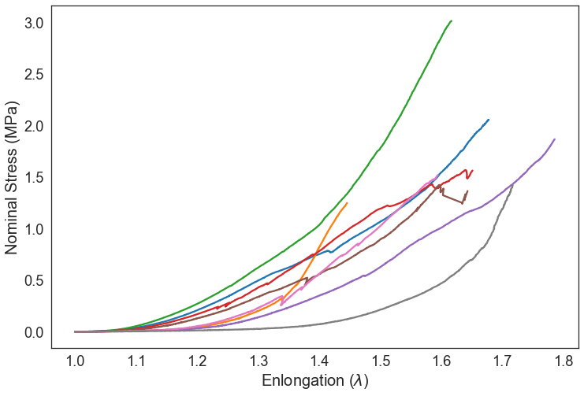

```python
plt.figure(figsize=(12,8))
for i in xrange(len(D)):
    plt.plot(D[i].x, D[i].y)
plt.xlabel('Enlongation ($\lambda$)')
plt.ylabel('Nominal Stress (MPa)')
```

# Bayesian Multilevel Modeling

For more information on Bayesian multilevel modeling we refer readers to chapter 12 of statistical rethinking book (https://xcelab.net/rm/statistical-rethinking/). In a nutshell, here's the problem (quoting from statistical rethinking book) we face:

In the year 1985, Clive Wearing lost his mind, but not his music.154 Wearing was a musicologist and accomplished musician, but the same virus that causes cold sores, Herpes simplex, snuck into his brain and ate his hippocampus. The result was chronic anterograde amnesia—he cannot form new long-term memories. He remembers how to play the piano, though he cannot remember that he played it 5 minutes ago. Wearing now lives moment to moment, unaware of anything more than a few minutes into the past. Every cup of coffee is the first he has ever had.

Many statistical models also have anterograde amnesia. Anterograde amnesia is bad for learning about the world. We want models that instead use all of the information in savvy ways. This does not mean treating all clusters as if they were the same. Instead it means learning simultaneously about each cluster while learning about the population of clusters. Doing both estimation tasks at the same time allows us to transfer information across clusters, and that transfer improves accuracy. That is the value of remembering.

## 1. Modeling with Anterograde Amnesia

```python
## Experiment 1 Data

def model(individual_exp_data):
    xobs = individual_exp_data.x
    yobs = individual_exp_data.y

    # Prior distribution over uncertain parameters of interest
    k0 = pm.Uniform('$k_0$', 0, 1)
    k1 = pm.Uniform('$k_1$', 0, 100)
    k2 = pm.Uniform('$k_2$', 0, 100)

    # define the mean of the likelihood
    @pm.deterministic
    def fm(k0 = k0, k1 = k1, k2 = k2):
        Ym = PK1(k0,k1,k2,xobs)
        return Ym

    # Likelihood of measurement
    alpha = 1
    sigma_sq = pm.Exponential('$\sigma^2$', alpha)
    prec = sigma_sq ** -1  #precision of the observed data

    observation = pm.Normal("obs", mu=fm, tau=prec, value=yobs, observed=True)

    return locals()
```

```python
def PK1_PRED(k0_samples,k1_samples,k2_samples,xobs):
    xobs1 = xobs[:,None]
    inter1 = (xobs1**3.-1.)/((9.*xobs1**4.))
    inter2 = 9.*xobs1.T*k0_samples
    inter3 = 2.*k1_samples*(xobs1.T-1.)**2.*(xobs1.T+2.)
    inter4 = k2_samples*(xobs1.T**3.-3.*xobs1.T+2.)**2.
    inter5 = 9.*xobs1**2.
    inter6 = np.exp(inter4/inter5.T)
    inter7 = (inter2 + inter3*inter6)
    y = inter1.T*inter7
    return y
```

```python
def post_pred(individual_exp_data, mcmc):
    k0_samples = mcmc.trace('$k_0$')[:,None]
    k1_samples = mcmc.trace('$k_1$')[:,None]
    k2_samples = mcmc.trace('$k_2$')[:,None]
    xobs = individual_exp_data.x
    yobs = individual_exp_data.y
    Y_trace = PK1_PRED(k0_samples,k1_samples,k2_samples,xobs)
    return Y_trace
```

## Experiment 1 Data

```python
mcmc1 = pm.MCMC(model(D[0]))
mcmc1.sample(20000, 15000, 5)
```

[output not shown]

```
Plotting $k_2$
Plotting $\sigma^2$
Plotting $k_1$
Plotting $k_0$
```

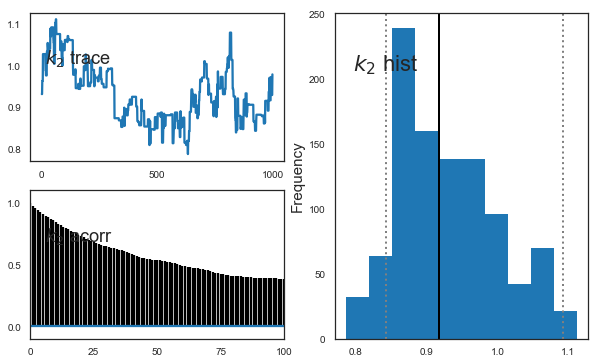

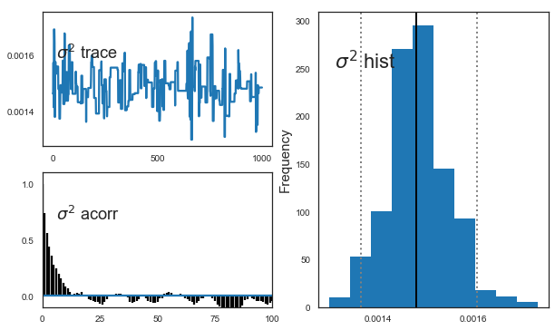

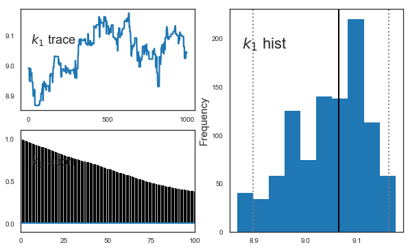

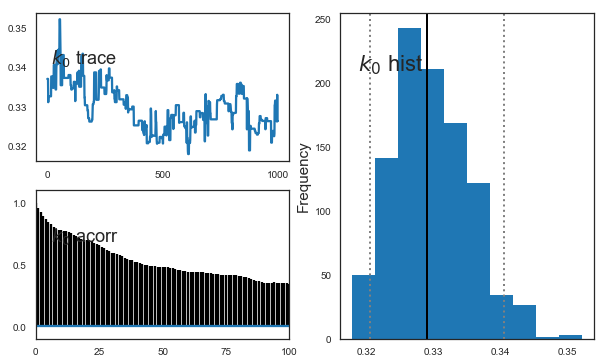

```python
from pymc.Matplot import plot
plot(mcmc1)
```

```python
Y_trace1 = post_pred(D[0], mcmc1)
```

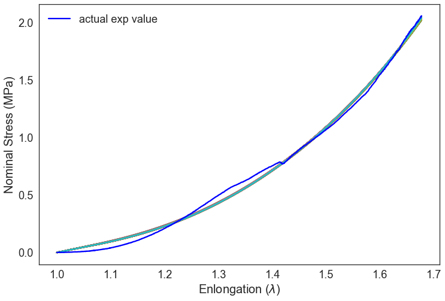

```python
plt.figure(figsize=(12,8))
for i in xrange(1000):
    plt.plot(D[0].x, Y_trace1[i,:])
plt.plot(D[0].x, D[0].y, color = 'b', label = 'actual exp value')
plt.xlabel('Enlongation ($\lambda$)')
plt.ylabel('Nominal Stress (MPa)')
plt.legend()
```

# Experiment 2 Data

```python
mcmc2 = pm.MCMC(model(D[1]))
mcmc2.sample(20000, 15000, 5)
```

```
 [-----------------100%-----------------] 20000 of 20000 complete in 178.2 sec
```

```
Plotting $k_1$
Plotting $k_2$
Plotting $k_0$
Plotting $\sigma^2$
```

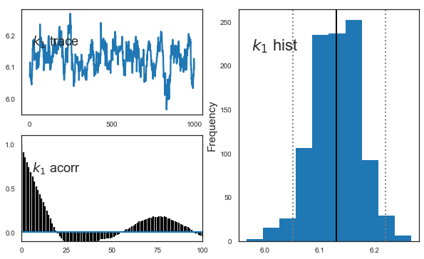

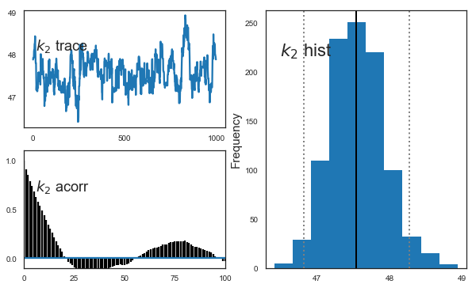

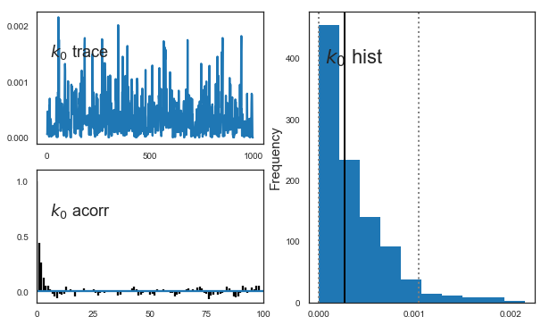

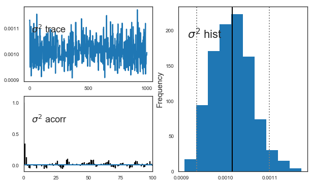

```python
from pymc.Matplot import plot
plot(mcmc2)
```

```python
Y_trace2 = post_pred(D[1], mcmc2)
```

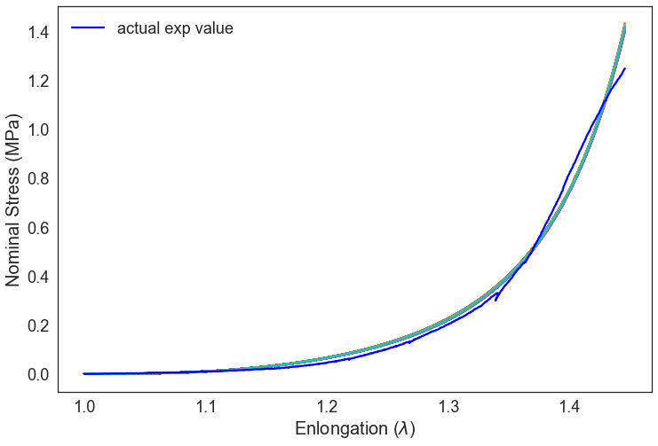

```python
plt.figure(figsize=(12,8))
for i in xrange(1000):
    plt.plot(D[1].x, Y_trace2[i,:])
plt.plot(D[1].x, D[1].y, color = 'b', label = 'actual exp value')
plt.xlabel('Enlongation ($\lambda$)')
plt.ylabel('Nominal Stress (MPa)')
plt.legend()
```

Similarily we can estimate model parameters by condioning it on each of the remaining datset. However, as noted before, this modeling framework fails to transfer information accross different experiments (adaptively pool information accross experiments). It suffers from anterograde amnesia. Therefore, we now move on to multilevel (hiearchial) bayesian modeling framework which would address this concern.

## 2. Modeling framework without Anterograde Amnesia

```python
def datagen(all_exp_data_list):
    d1 = all_exp_data_list[0]
    d2 = all_exp_data_list[1]
    d3 = all_exp_data_list[2]
    d4 = all_exp_data_list[3]
    d5 = all_exp_data_list[4]
    d6 = all_exp_data_list[5]
    d7 = all_exp_data_list[6]
    d8 = all_exp_data_list[7]
    return d1, d2, d3, d4, d5, d6, d7, d8

def xygen(d):
    x = d.x
    y = d.y
    return x,y
```

```python
## Experiment 1 Data

def multilevel_model(all_exp_data_list):
    (d1, d2, d3, d4, d5, d6, d7, d8) = datagen(all_exp_data_list) # load all the experimental data
    x1, y1 = xygen(d1)
    x2, y2 = xygen(d2)
    x3, y3 = xygen(d3)
    x4, y4 = xygen(d4)
    x5, y5 = xygen(d5)
    x6, y6 = xygen(d6)
    x7, y7 = xygen(d7)
    x8,y8 = xygen(d8)

    y_total = np.concatenate((y1, y2, y3, y4, y5, y6, y7, y8))


    # Build a multilevel Bayesian model (adaptively pool information across experiments)

    # We place a prior over mean of parameter values k0, k1, k2 (First level)
    alpha0 = pm.Uniform('alpha0', 0, 1)
    alpha1 = pm.Uniform('alpha1', 0, 100)
    alpha2 = pm.Uniform('alpha2', 0, 100)

    #  We place a prior over std for different parameters k0, k1 and k2 (First level)
    sigma0 = pm.Exponential('sigma0', 1.)
    sigma1 = pm.Exponential('sigma1',1./10)
    sigma2 = pm.Exponential('sigma2',1./10)

    # Precision associated with the above standard deviation is then given as
    prec0 = sigma0**-2
    prec1 = sigma1**-2
    prec2 = sigma2**-2

    # We now model the parameter values for each experiment (Second level)
    k0_vec = pm.Normal('k0_vec', alpha0, prec0, size = 8)
    k1_vec = pm.Normal('k1_vec', alpha1, prec1, size = 8)
    k2_vec = pm.Normal('k2_vec', alpha2, prec2, size = 8)

    # Noise in measurements
    noise_sd = pm.Exponential('noise_sd',1., size = 1)
    # Associated precision
    noise_prec = noise_sd**-2

    # define the mean of the likelihood
    @pm.deterministic
    def fm(k0_vec = k0_vec, k1_vec = k1_vec, k2_vec = k2_vec):
        Ym1 = PK1(k0_vec[0],k1_vec[0],k2_vec[0],x1)
        Ym2 = PK1(k0_vec[1],k1_vec[1],k2_vec[1],x2)
        Ym3 = PK1(k0_vec[2],k1_vec[2],k2_vec[2],x3)
        Ym4 = PK1(k0_vec[3],k1_vec[3],k2_vec[3],x4)
        Ym5 = PK1(k0_vec[4],k1_vec[4],k2_vec[4],x5)
        Ym6 = PK1(k0_vec[5],k1_vec[5],k2_vec[5],x6)
        Ym7 = PK1(k0_vec[6],k1_vec[6],k2_vec[6],x7)
        Ym8 = PK1(k0_vec[7],k1_vec[7],k2_vec[7],x8)
        Yt = np.concatenate((Ym1, Ym2, Ym3, Ym4, Ym5, Ym6, Ym7, Ym8))
        return Yt

    observation = pm.Normal("obs", mu=fm, tau=noise_prec, value= y_total, observed=True)

    return locals()
```

```python
mcmc = pm.MCMC(multilevel_model(D))
mcmc.sample(20000, 15000, 5)
```

```
 [-----------------100%-----------------] 20000 of 20000 complete in 1663.5 sec
```

```
Plotting alpha0
Plotting sigma0
Plotting noise_sd_0
Plotting k2_vec_0
Plotting k2_vec_1
Plotting k2_vec_2
Plotting k2_vec_3
Plotting k2_vec_4
Plotting k2_vec_5
Plotting k2_vec_6
Plotting k2_vec_7
Plotting alpha2
Plotting alpha1
Plotting sigma2
Plotting k0_vec_0
Plotting k0_vec_1
Plotting k0_vec_2
Plotting k0_vec_3
Plotting k0_vec_4
Plotting k0_vec_5
Plotting k0_vec_6
Plotting k0_vec_7
Plotting sigma1
Plotting k1_vec_0
Plotting k1_vec_1
Plotting k1_vec_2
Plotting k1_vec_3
Plotting k1_vec_4
Plotting k1_vec_5
Plotting k1_vec_6
Plotting k1_vec_7
```

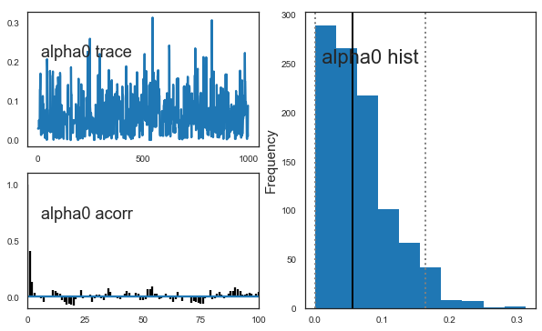

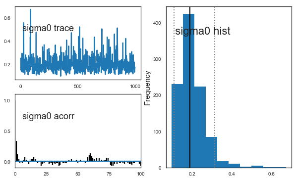

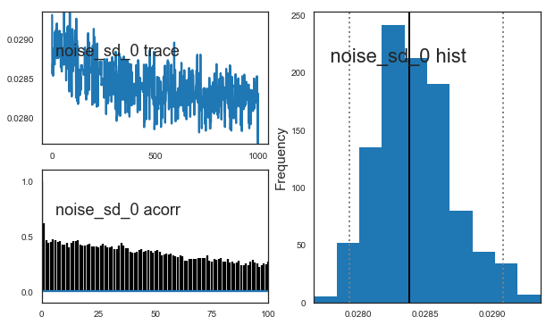

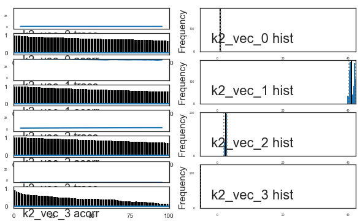

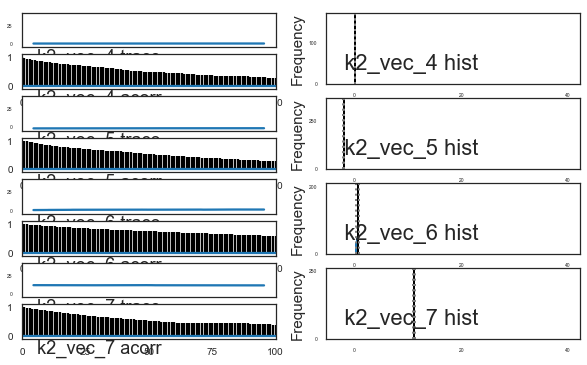

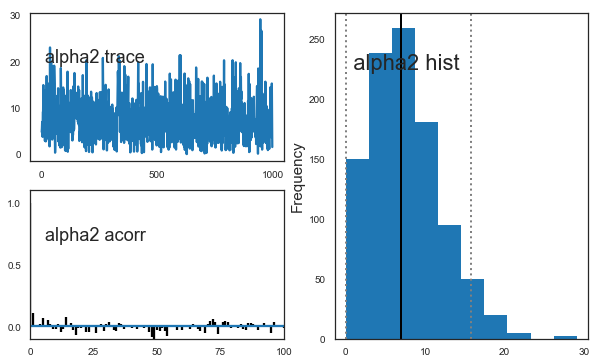

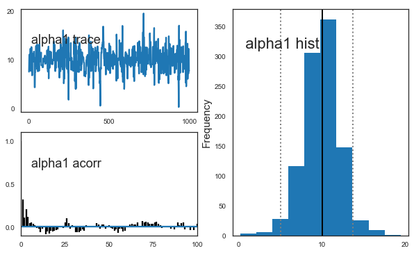

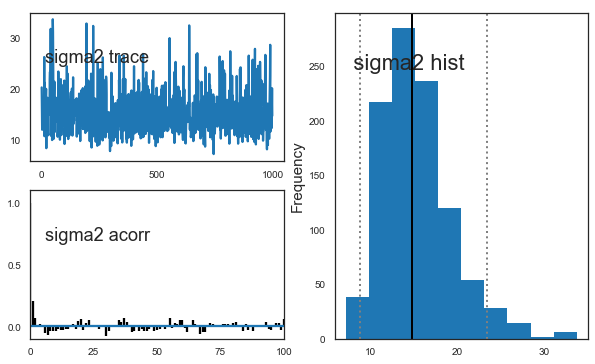

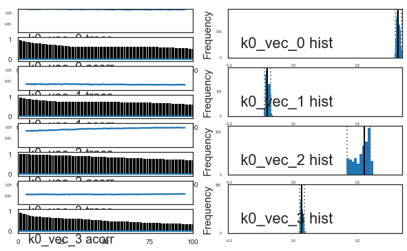

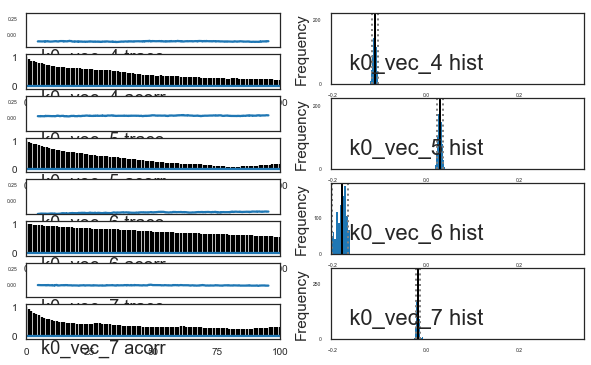

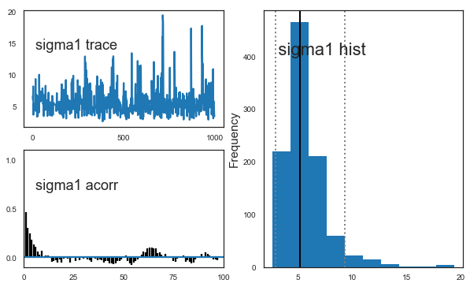

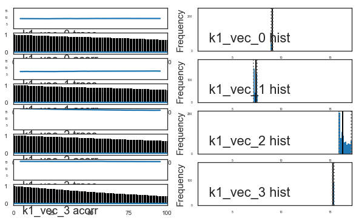

[1 more figures not shown]

```python
from pymc.Matplot import plot
plot(mcmc)
```

```python
alpha0_trace = mcmc.trace('alpha0')[:None]
alpha1_trace = mcmc.trace('alpha1')[:None]
alpha2_trace = mcmc.trace('alpha2')[:None]

sigma0_trace = mcmc.trace('sigma0')[:None]
sigma1_trace = mcmc.trace('sigma1')[:None]
sigma2_trace = mcmc.trace('sigma2')[:None]

k0_vec_samples = mcmc.trace('k0_vec')[:,None]
k1_vec_samples = mcmc.trace('k1_vec')[:,None]
k2_vec_samples = mcmc.trace('k2_vec')[:,None]

noise_sd_trace = mcmc.trace('noise_sd')[:,None]
```

```
Text(0.5,0,u'alpha0 value')
```

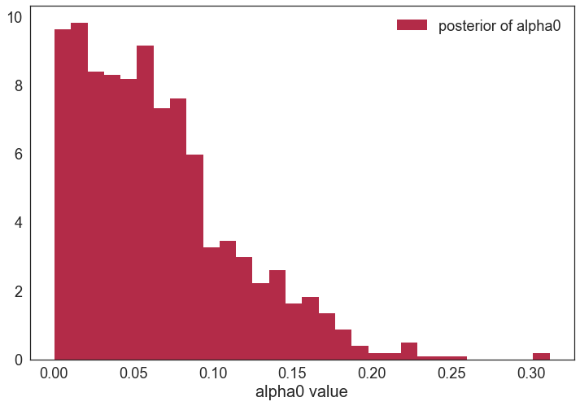

```python
plt.figure(figsize=(12,8))
A = plt.hist(alpha0_trace, histtype='stepfilled', bins=30, alpha=0.85,
             label="posterior of alpha0", color="#A60628",  normed=True)
plt.legend(loc="best")
plt.xlabel("alpha0 value")
```

```
Text(0.5,0,u'alpha1 value')
```

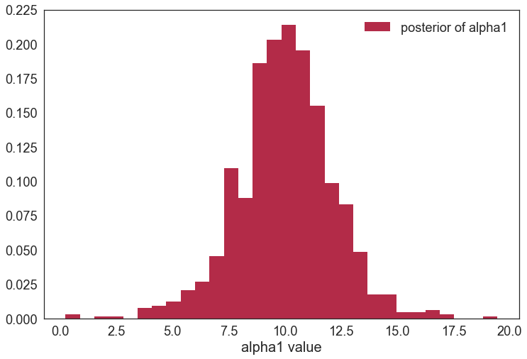

```python
plt.figure(figsize=(12,8))
A = plt.hist(alpha1_trace, histtype='stepfilled', bins=30, alpha=0.85,
             label="posterior of alpha1", color="#A60628",  normed=True)
plt.legend(loc="best")
plt.xlabel("alpha1 value")
```

```
Text(0.5,0,u'alpha2 value')
```

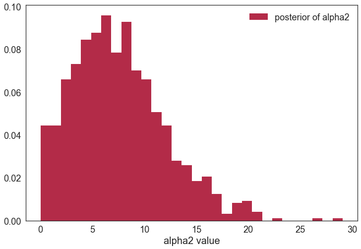

```python
plt.figure(figsize=(12,8))
A = plt.hist(alpha2_trace, histtype='stepfilled', bins=30, alpha=0.85,
             label="posterior of alpha2", color="#A60628",  normed=True)
plt.legend(loc="best")
plt.xlabel("alpha2 value")
```

```
Text(0.5,0,u'sigma0 value')
```

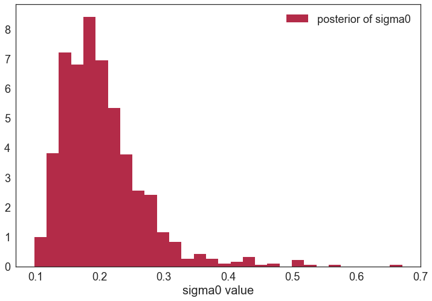

```python
plt.figure(figsize=(12,8))
A = plt.hist(sigma0_trace, histtype='stepfilled', bins=30, alpha=0.85,
             label="posterior of sigma0", color="#A60628",  normed=True)
plt.legend(loc="best")
plt.xlabel("sigma0 value")
```

```
Text(0.5,0,u'sigma1 value')
```

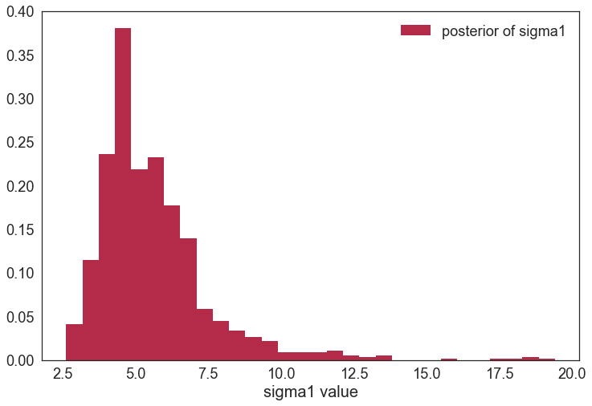

```python
plt.figure(figsize=(12,8))
A = plt.hist(sigma1_trace, histtype='stepfilled', bins=30, alpha=0.85,
             label="posterior of sigma1", color="#A60628",  normed=True)
plt.legend(loc="best")
plt.xlabel("sigma1 value")
```

```
Text(0.5,0,u'sigma2 value')
```

[figure not shown]

```python
plt.figure(figsize=(12,8))
A = plt.hist(sigma2_trace, histtype='stepfilled', bins=30, alpha=0.85,
             label="posterior of sigma1", color="#A60628",  normed=True)
plt.legend(loc="best")
plt.xlabel("sigma2 value")
```

# Parameters for individual experiments

# $k_0$

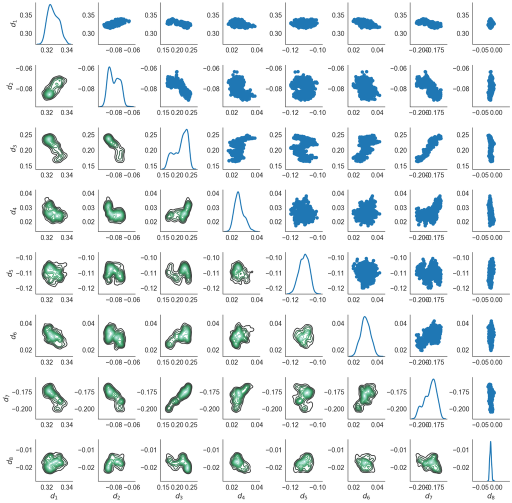

```python
df = pd.DataFrame(k0_vec_samples[:,0,:], columns=['$d_{%d}$' % (i + 1) for i in range(k0_vec_samples[:,0,:].shape[1])])
gg = sns.PairGrid(df, diag_sharey=False)
gg.map_lower(sns.kdeplot)
gg.map_upper(plt.scatter)
gg.map_diag(sns.kdeplot, lw=3);
```

# $k_1$

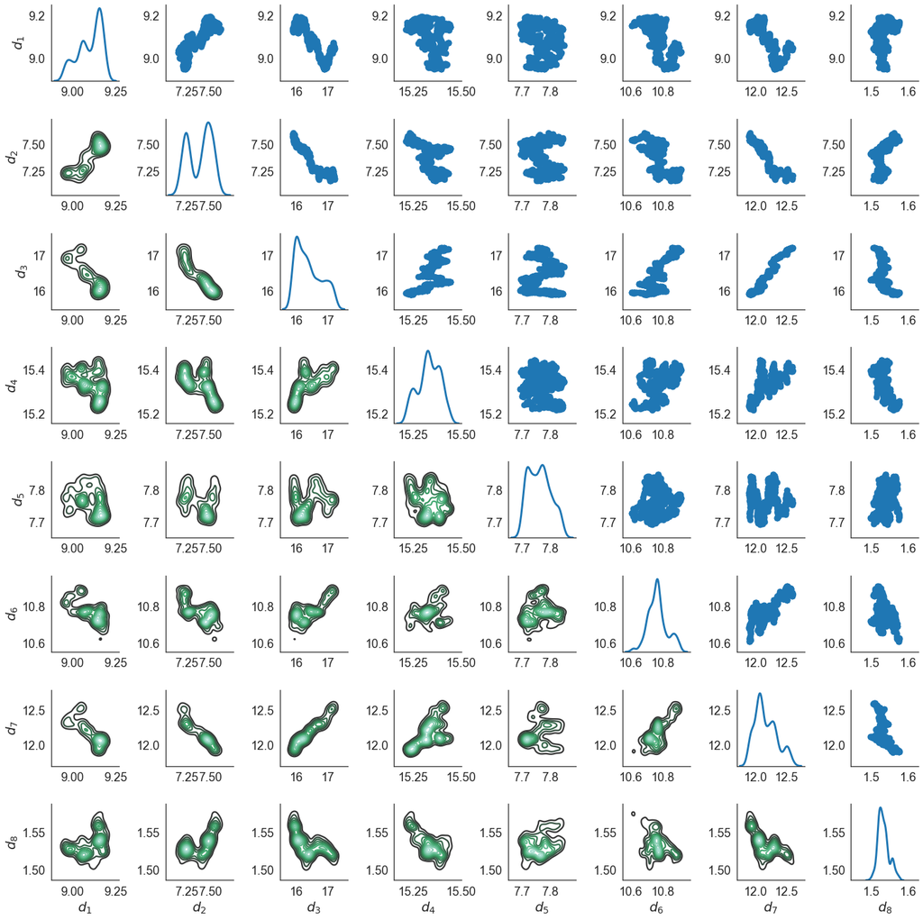

```python
df = pd.DataFrame(k1_vec_samples[:,0,:], columns=['$d_{%d}$' % (i + 1) for i in range(k1_vec_samples[:,0,:].shape[1])])
gg = sns.PairGrid(df, diag_sharey=False)
gg.map_lower(sns.kdeplot)
gg.map_upper(plt.scatter)
gg.map_diag(sns.kdeplot, lw=3);
```

# $k_2$

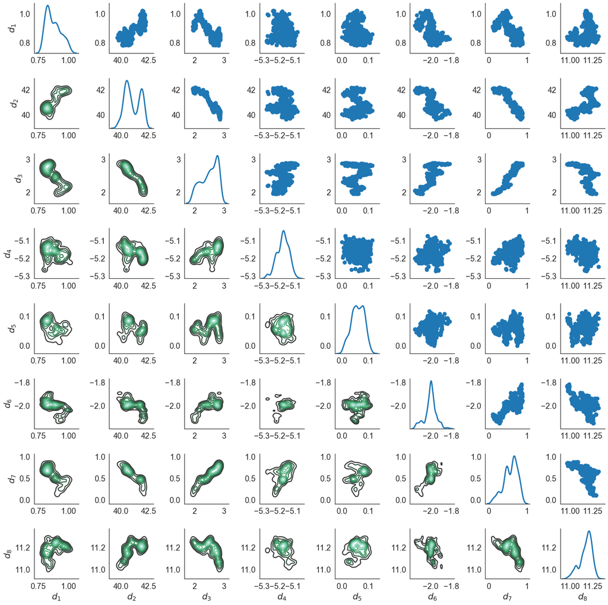

```python
df = pd.DataFrame(k2_vec_samples[:,0,:], columns=['$d_{%d}$' % (i + 1) for i in range(k2_vec_samples[:,0,:].shape[1])])
gg = sns.PairGrid(df, diag_sharey=False)
gg.map_lower(sns.kdeplot)
gg.map_upper(plt.scatter)
gg.map_diag(sns.kdeplot, lw=3);
```